# Google Data Analytics Capstone Report

Hsin Chih Chen

11/5/2021

# Synopsis

This capstone project is to use the knowledge from Google Data Analytics courses to answer business questions coming from bike-share service while using supporting evidence to persuade stakeholders & executive while the decisions have to be made.

The data can be download in the link below: https://divvy-tripdata.s3.amazonaws.com/index.htm

# Data Obtainment

The data was obtained from 2020 October up to 2021 October for the bike sharing service’s website, and the remaining operation and result will be based on the given time frame.

Meanwhile, the original csv files were already download to the working directory. Therefore the operations would be depending on where users download the file to.

# Data Cleaning & Transformation

After the data are loaded, some of the data format were not the same for same columns. Therefore, transfer these variable time to be the same before cleaning NA items to ensure all data points are valid.

This section will also calculate the ride length based on the transformed time frame interval. The conversion will be ensure the ride length format are in seconds.

```r
## Rename the conflicted variables as character variables
Oct_2020 <- mutate(Oct_2020, ride_id = as.character(ride_id), rideable_type = as.character(rideable_type), start_station_id = as.character(start_station_id),end_station_id = as.character(end_station_id))
Nov_2020 <- mutate(Nov_2020, ride_id = as.character(ride_id), rideable_type = as.character(rideable_type), start_station_id = as.character(start_station_id),end_station_id = as.character(end_station_id))
Dec_2020 <- mutate(Dec_2020, ride_id = as.character(ride_id), rideable_type = as.character(rideable_type), start_station_id = as.character(start_station_id),end_station_id = as.character(end_station_id))
Jan_2021 <- mutate(Jan_2021, ride_id = as.character(ride_id), rideable_type = as.character(rideable_type), start_station_id = as.character(start_station_id),end_station_id = as.character(end_station_id))
Feb_2021 <- mutate(Feb_2021, ride_id = as.character(ride_id), rideable_type = as.character(rideable_type), start_station_id = as.character(start_station_id),end_station_id = as.character(end_station_id))
Mar_2021 <- mutate(Mar_2021, ride_id = as.character(ride_id), rideable_type = as.character(rideable_type), start_station_id = as.character(start_station_id),end_station_id = as.character(end_station_id))
Apr_2021 <- mutate(Apr_2021, ride_id = as.character(ride_id), rideable_type = as.character(rideable_type), start_station_id = as.character(start_station_id),end_station_id = as.character(end_station_id))
May_2021 <- mutate(May_2021, ride_id = as.character(ride_id), rideable_type = as.character(rideable_type), start_station_id = as.character(start_station_id),end_station_id = as.character(end_station_id))
Jun_2021 <- mutate(Jun_2021, ride_id = as.character(ride_id), rideable_type = as.character(rideable_type), start_station_id = as.character(start_station_id),end_station_id = as.character(end_station_id))
Jul_2021 <- mutate(Jul_2021, ride_id = as.character(ride_id), rideable_type = as.character(rideable_type), start_station_id = as.character(start_station_id),end_station_id = as.character(end_station_id))
Aug_2021 <- mutate(Aug_2021, ride_id = as.character(ride_id), rideable_type = as.character(rideable_type), start_station_id = as.character(start_station_id),end_station_id = as.character(end_station_id))
Sep_2021 <- mutate(Sep_2021, ride_id = as.character(ride_id), rideable_type = as.character(rideable_type), start_station_id = as.character(start_station_id),end_station_id = as.character(end_station_id))
Oct_2021 <- mutate(Oct_2021, ride_id = as.character(ride_id), rideable_type = as.character(rideable_type), start_station_id = as.character(start_station_id),end_station_id = as.character(end_station_id))

## Stack all data as one data frame
alltrips <- bind_rows(Oct_2020, Nov_2020, Dec_2020, Jan_2021, Feb_2021, Mar_2021, Apr_2021, May_2021, Jun_2021, Jul_2021, Aug_2021, Sep_2021, Oct_2021)

## Remove unnecessary columns for the data extracts
alltrips <- alltrips %>%
  select(-c(start_lat, start_lng, end_lat, end_lng))
```

```r
## Inspect the dimension of data
colnames(alltrips)
```

```
## [1] "ride_id"            "rideable_type"      "started_at"
## [4] "ended_at"           "start_station_name" "start_station_id"
## [7] "end_station_name"   "end_station_id"     "member_casual"
```

```r
nrow(alltrips)
```

```
## [1] 5767487
```

```r
dim(alltrips)
```

```
## [1] 5767487       9
```

```r
head(alltrips)
```

```
## # A tibble: 6 x 9
##   ride_id rideable_type started_at          ended_at            start_station_n~
##   <chr>   <chr>         <dttm>              <dttm>              <chr>
## 1 ACB6B4~ electric_bike 2020-10-31 19:39:43 2020-10-31 19:57:12 Lakeview Ave & ~
## 2 DF450C~ electric_bike 2020-10-31 23:50:08 2020-11-01 00:04:16 Southport Ave &~
## 3 B6396B~ electric_bike 2020-10-31 23:00:01 2020-10-31 23:08:22 Stony Island Av~
## 4 44A4AE~ electric_bike 2020-10-31 22:16:43 2020-10-31 22:19:35 Clark St & Grac~
## 5 10B7DD~ electric_bike 2020-10-31 19:38:19 2020-10-31 19:54:32 Southport Ave &~
## 6 DA6C37~ electric_bike 2020-10-29 17:38:04 2020-10-29 17:45:43 Larrabee St & D~
## # ... with 4 more variables: start_station_id <chr>, end_station_name <chr>,
## #   end_station_id <chr>, member_casual <chr>
```

```r
tail(alltrips)
```

```
## # A tibble: 6 x 9
##   ride_id rideable_type started_at          ended_at            start_station_n~
##   <chr>   <chr>         <dttm>              <dttm>              <chr>
## 1 817A85~ classic_bike  2021-10-15 18:01:23 2021-10-15 18:09:41 Franklin St & J~
## 2 BA077F~ classic_bike  2021-10-14 21:45:05 2021-10-14 22:07:25 Franklin St & C~
## 3 B7D992~ classic_bike  2021-10-02 15:28:28 2021-10-02 15:51:02 Streeter Dr & G~
## 4 BCCFD6~ electric_bike 2021-10-08 16:47:10 2021-10-08 16:52:43 Calumet Ave & 2~
## 5 623E0F~ classic_bike  2021-10-08 07:49:47 2021-10-08 07:55:15 Calumet Ave & 2~
## 6 83FA6A~ classic_bike  2021-10-02 12:55:45 2021-10-02 13:21:10 Winthrop Ave & ~
## # ... with 4 more variables: start_station_id <chr>, end_station_name <chr>,
## #   end_station_id <chr>, member_casual <chr>
```

```r
str(alltrips)
```

```
## tibble [5,767,487 x 9] (S3: tbl_df/tbl/data.frame)
##  $ ride_id           : chr [1:5767487] "ACB6B40CF5B9044C" "DF450C72FD109C01" "B6396B54A15AC0DF" "44A4AEE261B9E854" ...
##  $ rideable_type     : chr [1:5767487] "electric_bike" "electric_bike" "electric_bike" "electric_bike" ...
##  $ started_at        : POSIXct[1:5767487], format: "2020-10-31 19:39:43" "2020-10-31 23:50:08" ...
##  $ ended_at          : POSIXct[1:5767487], format: "2020-10-31 19:57:12" "2020-11-01 00:04:16" ...
##  $ start_station_name: chr [1:5767487] "Lakeview Ave & Fullerton Pkwy" "Southport Ave & Waveland Ave" "Stony Island Ave & 67th St" "Clark St & Grace St" ...
##  $ start_station_id  : chr [1:5767487] "313" "227" "102" "165" ...
##  $ end_station_name  : chr [1:5767487] "Rush St & Hubbard St" "Kedzie Ave & Milwaukee Ave" "University Ave & 57th St" "Broadway & Sheridan Rd" ...
##  $ end_station_id    : chr [1:5767487] "125" "260" "423" "256" ...
##  $ member_casual     : chr [1:5767487] "casual" "casual" "casual" "casual" ...
```

```r
summary(alltrips)
```

```
##    ride_id          rideable_type        started_at
##  Length:5767487     Length:5767487     Min.   :2020-10-01 00:00:06
##  Class :character   Class :character   1st Qu.:2021-04-26 19:16:25
##  Mode  :character   Mode  :character   Median :2021-07-05 14:28:03
##                                        Mean   :2021-06-10 12:36:52
##                                        3rd Qu.:2021-08-29 15:51:40
##                                        Max.   :2021-10-31 23:59:49
##     ended_at                   start_station_name start_station_id
##  Min.   :2020-10-01 00:05:09   Length:5767487     Length:5767487
##  1st Qu.:2021-04-26 19:39:39   Class :character   Class :character
##  Median :2021-07-05 14:57:35   Mode  :character   Mode  :character
##  Mean   :2021-06-10 12:57:19
##  3rd Qu.:2021-08-29 16:13:46
##  Max.   :2021-11-03 21:45:48
##  end_station_name   end_station_id     member_casual
##  Length:5767487     Length:5767487     Length:5767487
##  Class :character   Class :character   Class :character
##  Mode  :character   Mode  :character   Mode  :character
##
##
##
```

```r
## Use re-code to rename the membership mode
alltrips <- alltrips %>%
  mutate(member_casual = recode(member_casual,"Subscriber" = "member", "Customer" = "casual"))

table(alltrips$member_casual)
```

```
##
##  casual  member
## 2615529 3151958
```

```r
## Convert POSI Dates as date format
alltrips$date <- as.Date(alltrips$started_at)
alltrips$month <- format(as.Date(alltrips$date), "%m")
alltrips$day <- format(as.Date(alltrips$date), "%d")
alltrips$year <- format(as.Date(alltrips$date), "%Y")
alltrips$day_of_week <- format(as.Date(alltrips$date), "%A")

## Calculate Ride Length
alltrips$ride_length <- difftime(alltrips$ended_at, alltrips$started_at)

## Recheck Updated Structure
str(alltrips)
```

```
## tibble [5,767,487 x 15] (S3: tbl_df/tbl/data.frame)
##  $ ride_id           : chr [1:5767487] "ACB6B40CF5B9044C" "DF450C72FD109C01" "B6396B54A15AC0DF" "44A4AEE261B9E854" ...
##  $ rideable_type     : chr [1:5767487] "electric_bike" "electric_bike" "electric_bike" "electric_bike" ...
##  $ started_at        : POSIXct[1:5767487], format: "2020-10-31 19:39:43" "2020-10-31 23:50:08" ...
##  $ ended_at          : POSIXct[1:5767487], format: "2020-10-31 19:57:12" "2020-11-01 00:04:16" ...
##  $ start_station_name: chr [1:5767487] "Lakeview Ave & Fullerton Pkwy" "Southport Ave & Waveland Ave" "Stony Island Ave & 67th St" "Clark St & Grace St" ...
##  $ start_station_id  : chr [1:5767487] "313" "227" "102" "165" ...
##  $ end_station_name  : chr [1:5767487] "Rush St & Hubbard St" "Kedzie Ave & Milwaukee Ave" "University Ave & 57th St" "Broadway & Sheridan Rd" ...
##  $ end_station_id    : chr [1:5767487] "125" "260" "423" "256" ...
##  $ member_casual     : chr [1:5767487] "casual" "casual" "casual" "casual" ...
##  $ date              : Date[1:5767487], format: "2020-10-31" "2020-10-31" ...
##  $ month             : chr [1:5767487] "10" "10" "10" "10" ...
##  $ day               : chr [1:5767487] "31" "31" "31" "31" ...
##  $ year              : chr [1:5767487] "2020" "2020" "2020" "2020" ...
##  $ day_of_week       : chr [1:5767487] "星期六" "星期六" "星期六" "星期六" ...
##  $ ride_length       : 'difftime' num [1:5767487] 1049 848 501 172 ...
##   ..- attr(*, "units")= chr "secs"
```

```r
## Convert ride length from factor to numeric for calculation
is.factor(alltrips$ride_length)
```

```
## [1] FALSE
```

```r
alltrips$ride_length <- as.numeric(as.character(alltrips$ride_length))

## Verify the character type is numeric
is.numeric(alltrips$ride_length)
```

```
## [1] TRUE
```

```r
## Remove Bad Data from either incomplete ride length (less than 0) or taken out of docks.
alltrips_v2 <- alltrips[!(alltrips$start_station_name == "HQ QR" | alltrips$ride_length < 0), ]

## Remove the NA values to get a more precise data summary
alltrips_v3 <- na.omit(alltrips_v2)
```

# Data Analysis

This section will order the weekdays as required sequence, meanwhile summarizing the data

```
## # A tibble: 14 x 4
## # Groups:   member_casual [2]
##    member_casual weekday number_of_rides average_duration
##    <chr>         <ord>             <int>            <dbl>
##  1 casual        週日             422101            2282.
##  2 casual        週一             234683            1960.
##  3 casual        週二             222659            1763.
##  4 casual        週三             227208            1710.
##  5 casual        週四             237675            1685.
##  6 casual        週五             307261            1889.
##  7 casual        週六             501384            2125.
##  8 member        週日             332489             923.
##  9 member        週一             356405             777.
## 10 member        週二             396651             764.
## 11 member        週三             411003             768.
## 12 member        週四             397746             760.
## 13 member        週五             391594             796.
## 14 member        週六             389965             905.
```

[output not shown]

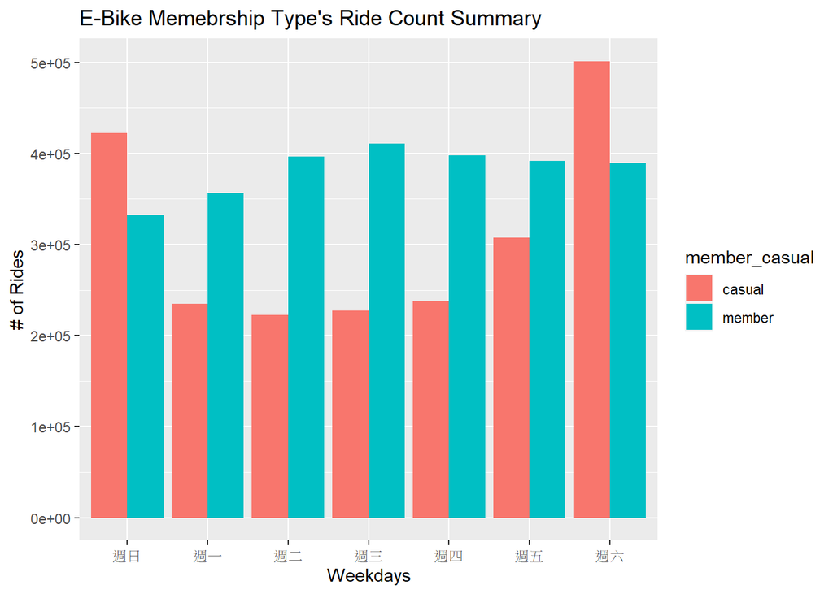

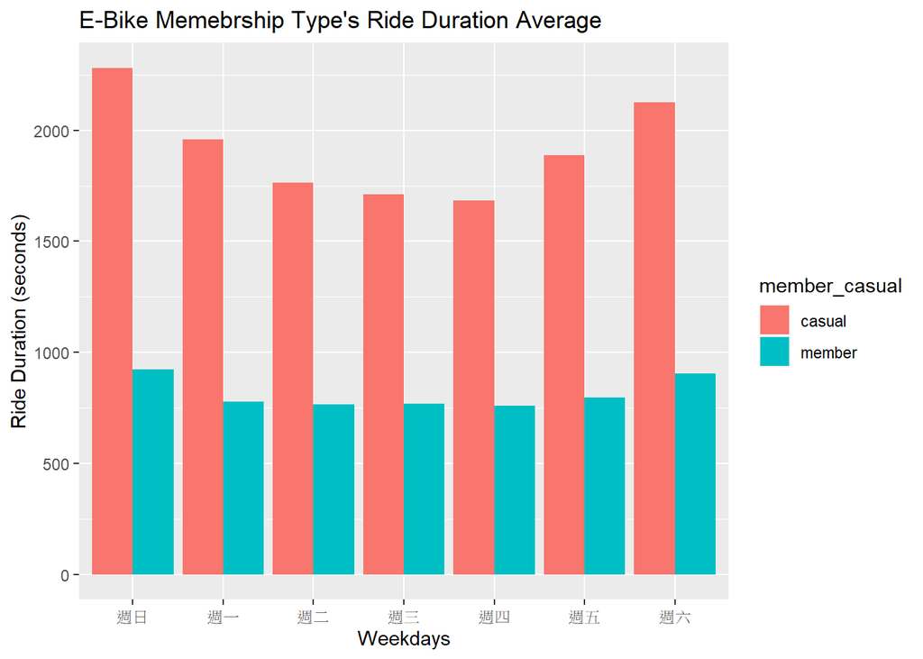

# Summary

Based on the visual display and the data, the following conclusion can be made for the recommendation associated with the observed trends.

1. Members and Casual customers do behave different, one of the biggest significant difference is that the casual rider’s average ride duration is significantly greater than the average of the member customers.
2. Members have tendency to ride more frequent during the weekdays, while the casual riders ride more frequent during the weekend by the counts.

After seeing this trend, perhaps the following strategy can be implemented for the casual riders to buy memberships.

1. Have a cheaper rate of charge for the casual riders during the weekdays for them to persuade the change for being a member cyclist.
2. Or use the more you ride, the cheaper you get approach to encourage casual riders for the membership approach so they can pay at a fixed rate.